# Benchmarking: cell calling and ambient RNA removal

2026-08-04

**Run:** `260528_VH01624_464_222K7VKNX` / `LK2-GEX`. The comparison was carried out on LK2; CellBender was also run on LK1-resequenced.

**Status:** settled for the pipeline, which runs both emptyDrops and CellBender and records their overlap per run.

**Analysis finished:** 2026-06-29 - the most recent of the 17 figures shown below.

**Report generated:** 2026-08-04 by `07.cell_calling_report.Rmd`, from the outputs of steps 01-06 in this folder.

Cell Ranger’s own cell calling is conservative and drops small cells, T-cells in particular. Two alternatives were tested: emptyDrops, which decides whether a droplet holds more structured RNA than the ambient profile predicts, and CellBender, which models the ambient contamination and subtracts it.

For full report, download `cell_calling_report.html` in the attachment and open in a browser.

Code used - attached and in the github repository: https://github.com/nbartonicek/surface_proteome_dev/tree/main/lab_archives/Benchmarking-cell_calling_and_ambient_RNA_removal

# Aim

Decide which barcodes to carry forward as real cells, and how much ambient RNA to remove:

- does emptyDrops recover the small cells Cell Ranger discards
- does CellBender agree with emptyDrops on which barcodes are cells
- what `expected-cells` and `total-droplets-included` should CellBender use
- what do the barcodes the two methods disagree about actually look like

# Conclusions

- Cell Ranger is fairly conservative and eliminates small cells, T-cells in particular; emptyDrops recovers roughly 1,000 more cells on run 1 (24,334)
- run 2 raises the opposite problem: emptyDrops calls **fewer** cells than Cell Ranger (31,198 against 32,846), and the extra barcodes are largely dead cells - so more calls is not automatically better
- the working combination is emptyDrops plus CellBender with a mitochondrial cleanup, rather than either tool alone
- MT cutoffs are taken from the literature rather than picked here: van Galen 20%, Petti 10%, Beneyto 20%, Zeng 20%
- the fraction of counts removed stays under 5% in every configuration tried (2.3% to 4.3%), so CellBender is not stripping a large part of the signal
- the droplet padding matters less than expected: `+15,000` and `+30,000` total droplets give substantially overlapping barcode sets, which is what the Venn diagrams below show
- raising `total-droplets-included` raises `found_cells` (35,358 to 38,215 on LK2) while *lowering* the fraction removed, so the two settings trade off against each other rather than one dominating

# 1. emptyDrops

Step 01 runs `DropletUtils::emptyDrops` on the raw Cell Ranger matrix and keeps barcodes at FDR <= 0.01. It estimates the ambient RNA profile from the low-count droplets and then tests, per droplet, whether its content is more structured than that profile would produce. That is what lets it recover small cells a simple UMI-rank cutoff discards.

# 2. CellBender and the droplet sweep

CellBender 0.3.0 was run in a container (step 02). `expected-cells` is estimated from the data; `total-droplets-included` sets how far down the UMI rank the model looks for ambient signal. Two settings were tried:

| Step | `total-droplets-included` | Output |
| --- | --- | --- |
| 02 | expected + 15,000 | `cellbender/<run>/<sample>/` |
| 03 | expected + 30,000 | `cellbender/<run>/<sample>_e30000/` |

Those are the `32k` and `32k30k` arms in the figure names below.

Four configurations were run in total, three of them on LK2. The numbers below are from the CellBender metrics of each run, as reported in the 2026-07-13 progress slides:

|  | LK1 23k+15k | LK2 33k+15k | LK2 25k+15k | LK2 33k+30k |
| --- | --- | --- | --- | --- |
| `expected_cells` | 23,569 | 32,846 | 25,000 | 32,846 |
| `found_cells` | 23,595 | 35,358 | 34,658 | 38,215 |
| `fraction_counts_removed` | 0.023 | 0.034 | 0.043 | 0.031 |

The diagnostic below is the panel to read: the black line is the UMI count per barcode in rank order, the red points are CellBender’s inferred cell probability. Where the red cloud breaks up is where the model stops being confident a droplet holds a cell.

**`cellbender_LK1_23k_15k.png`**

**LK1, expected 23,569 + 15,000 droplets.** 23,595 cells found, 2.3% of counts removed - the cleanest of the four, and the boundary is sharp.

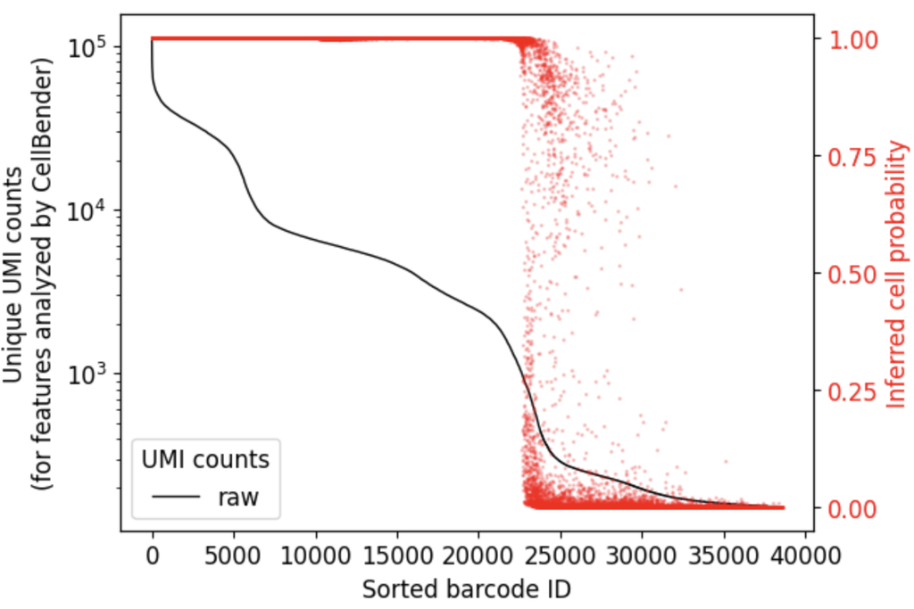

**`cellbender_LK2_33k_15k.png`**

**LK2, expected 32,846 + 15,000.** 35,358 cells, 3.4% removed. The adopted setting (step 02).

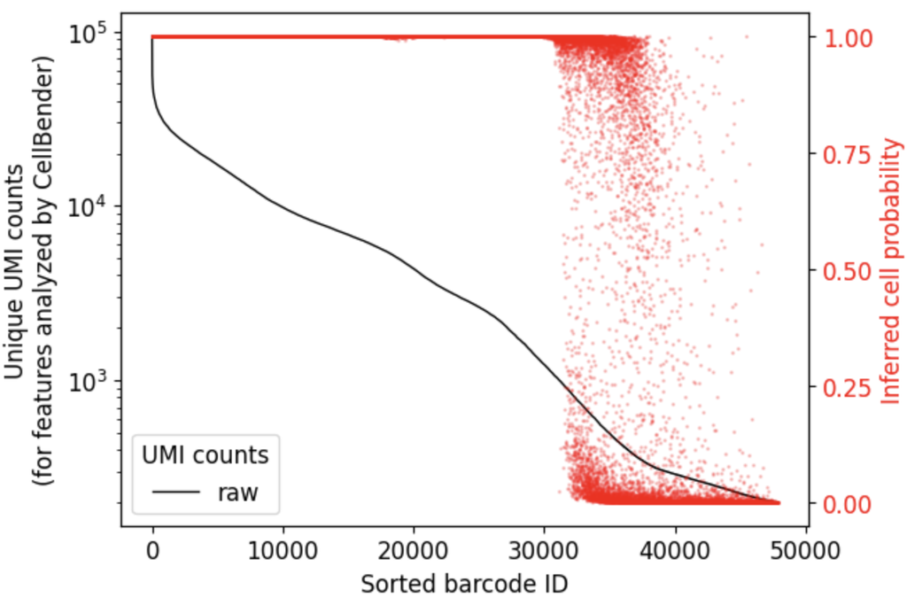

**`cellbender_LK2_25k_15k.png`**

**LK2, expected 25,000 + 15,000.** 34,658 cells, 4.3% removed - understating expected-cells costs the most signal of the three.

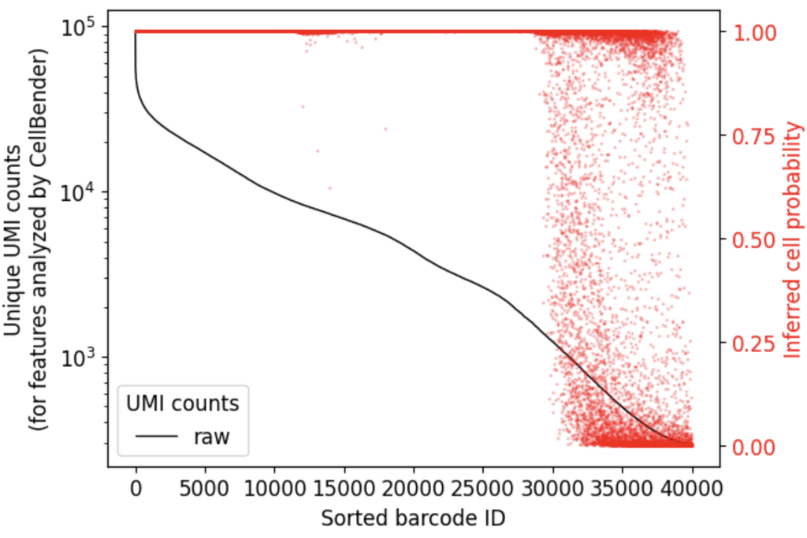

**`cellbender_LK2_33k_30k.png`**

**LK2, expected 32,846 + 30,000** (step 03). 38,215 cells, 3.1% removed. Widening the droplet window finds more cells and removes proportionally less.

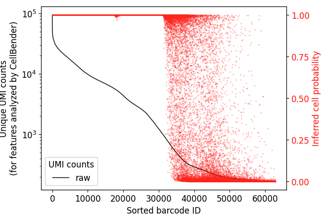

For reference, CellBender’s own illustration of what the UMI-rank curve looks like at low background, high background, and outright QC failure:

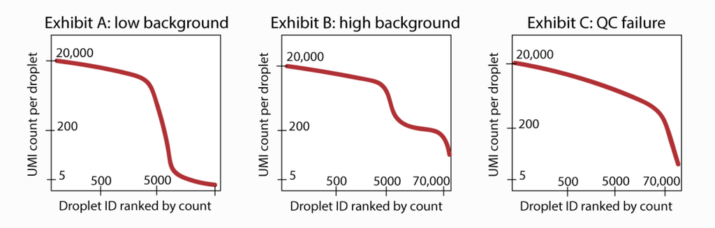

CellBender metrics

| metric | value |
| --- | --- |
| total_output_counts | 280,092,053 |
| total_counts_removed | 9,879,479 |
| fraction_counts_removed | 0.034 |
| total_raw_counts_in_cells | 289,971,532 |
| total_counts_removed_from_cells | 9,879,479 |
| fraction_counts_removed_from_cells | 0.034 |
| average_counts_removed_per_cell | 279.41 |
| target_fpr | 0.010 |
| expected_cells | 32,846 |
| found_cells | 35,358 |
| output_average_counts_per_cell | 7,922 |
| ratio_of_found_cells_to_expected_cells | 1.076 |
| found_empties | 12,488 |
| fraction_of_analyzed_droplets_that_are_nonempty | 0.739 |
| convergence_indicator | 0.177 |
| overall_change_in_train_elbo | 6,949 |

**`LK2-GEX_cellbender.pdf`**

CellBender’s own diagnostic page: training progress, cell probability against UMI rank, and a PCA of the latent encoding. The middle panel is the one to read - it shows where the model puts the boundary between cells and ambient droplets.

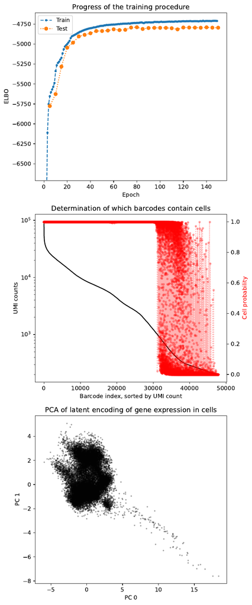

# 3. Overlap between the methods

**`venn_emptydrops_vs_cellbender_25k.pdf`**

**`venn_emptydrops_vs_cellbender_32k.pdf`**

**`venn_emptydrops_vs_cellbender_32k30k.pdf`**

emptyDrops against CellBender at 32k with 30,000 extra droplets.

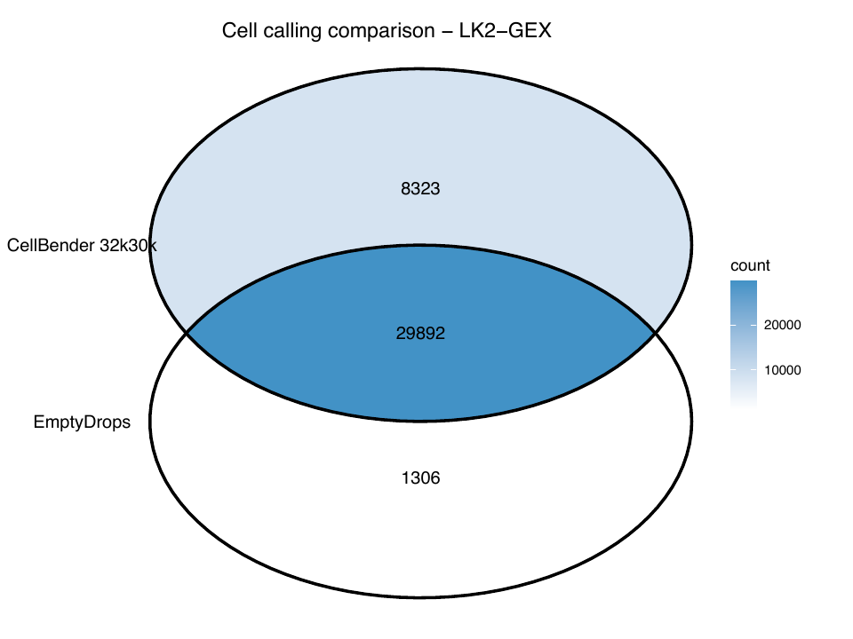

**`venn_cellbender_32k_vs_25k.pdf`**

**`venn_emptydrops_cellbender_3way.pdf`**

**`venn_emptydrops_cellbender_4way.pdf`**

Four-way overlap, adding the +30k arm.

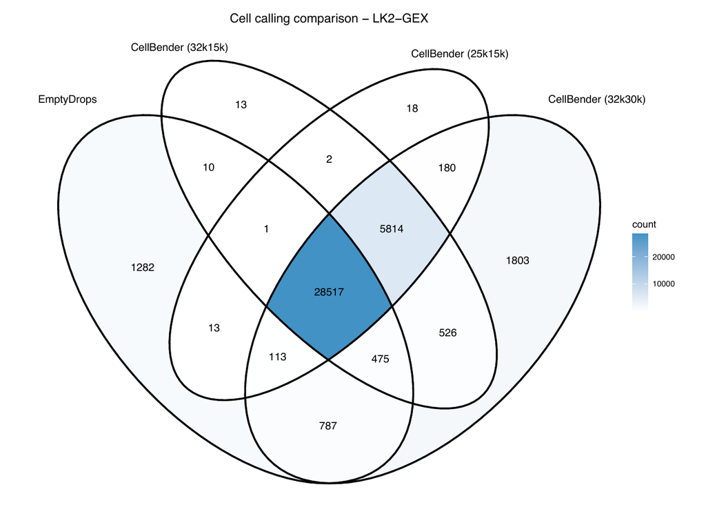

**`barplot_category_breakdown.pdf`**

# 4. What the disagreed barcodes look like

The overlap alone does not say which method is right. Step 06 takes every barcode category - called by both, by only one, by neither - and looks at its QC.

QC summary by barcode category

| caller | barcode_category | n_cells | median_genes | median_umis | median_mt_counts | median_percent_mt |
| --- | --- | --- | --- | --- | --- | --- |
| CellBender 32k30k object | Common | 29892 | 2635.0 | 6186 | 192 | 2.735794 |
| CellBender 32k30k object | CellBender only | 8323 | 23.0 | 405 | 150 | 91.760300 |
| EmptyDrops object | Common | 29892 | 2668.0 | 6375 | 212 | 2.933419 |
| EmptyDrops object | EmptyDrops only | 1306 | 207.5 | 243 | 6 | 2.750717 |

QC by barcode category

[output not shown]

**`violin_qc_metrics_by_barcode_category_combined.pdf`**

All QC metrics by barcode category in one panel. The summary figure for this section.

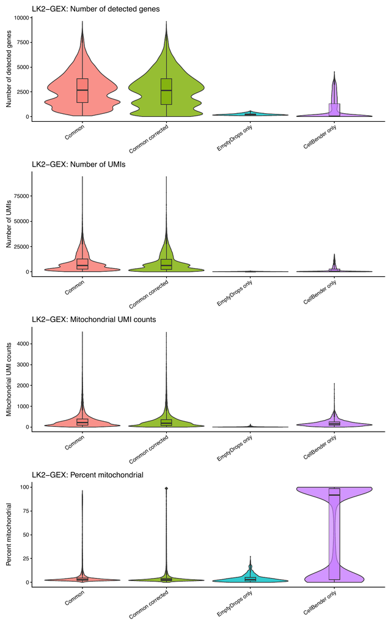

**`violin_genes_by_barcode_category.pdf`**

Genes detected per barcode category.

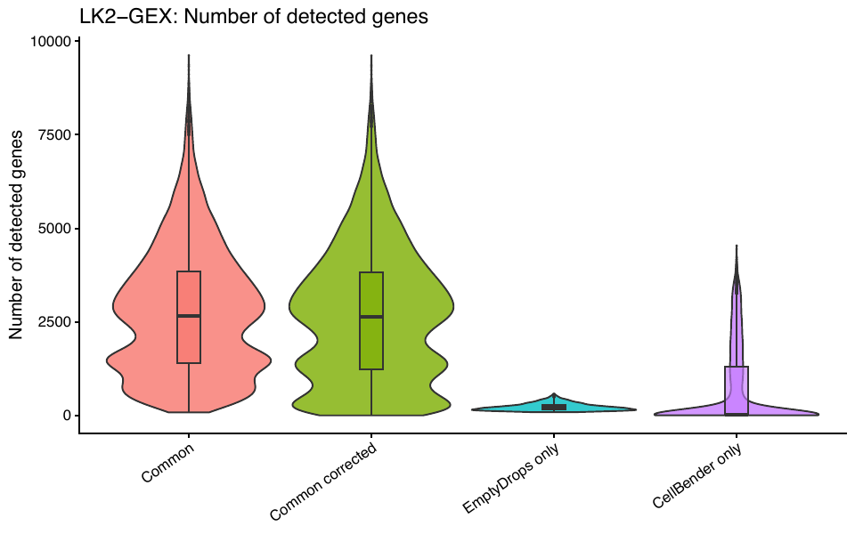

**`violin_umis_by_barcode_category.pdf`**

UMIs per barcode category.

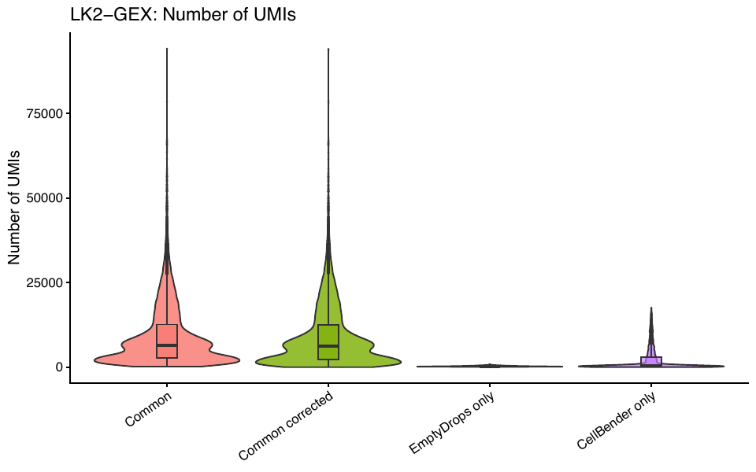

**`violin_percent_mt_by_barcode_category.pdf`**

Percent mitochondrial per category - this is what identifies the dead cells behind the run 2 problem.

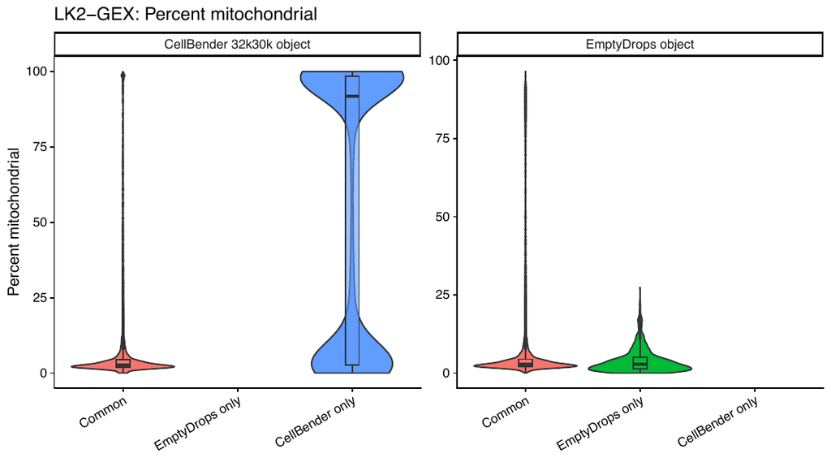

**`violin_mt_counts_by_barcode_category.pdf`**

Mitochondrial counts per category.

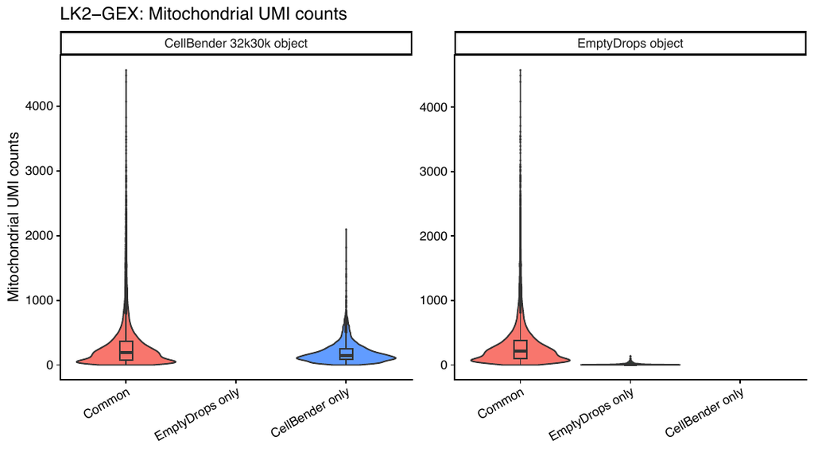

# 5. In the pipeline

Both tools run for every sample in the Nextflow pipeline, and their overlap is recorded per run rather than being re-derived by hand.

emptyDrops / CellBender overlap per pipeline run

| sample | n_emptydrops | n_cellbender | n_common | n_emptydrops_only | n_cellbender_only | pct_jaccard | run |
| --- | --- | --- | --- | --- | --- | --- | --- |
| LK1-GEX | 23779 | 24115 | 22938 | 841 | 1177 | 91.9 | 260522 |
| LK2-GEX | 31201 | 38747 | 29852 | 1349 | 8895 | 74.5 | 260528 |
| LK3-GEX | 28968 | 32050 | 27404 | 1564 | 4646 | 81.5 | 260717 |

# 6. What was run, in order

| Step | Script | What it does |
| --- | --- | --- |
| 01 | `01.emptydrops.R` | emptyDrops on the raw matrix, FDR <= 0.01. |
| 02 | `02.cellbender_run.sh` | CellBender 0.3.0 in a container, expected + 15,000 droplets. |
| 03 | `03.cellbender_run_30k_droplets.sh` | The +30,000 droplet arm of the sweep. |
| 04 | `04.cellbender_qc.R` | Post-CellBender QC: knee plot, UMI before/after, percent background removed. |
| 05 | `05.compare_emptydrops_cellbender.R` | Barcode overlap, Venns at 25k and 32k, category breakdown. |
| 06 | `06.compare_emptydrops_cellbender_extended.R` | Adds the +30k arm, four-way Venn, and per-category QC. |
| 07 | `07.cell_calling_report.Rmd` | This report. |

Two earlier attempts at the CellBender run are not kept: `scripts/2a.cellbender.sh` (2026-06-19, before containerisation) and `scripts/2b.cellbender_docker.sh` (2026-06-23, containerised but before the fix). Step 02 supersedes both.

Steps 05 and 06 are **both** kept, which is the exception to merging revisions into one step. They ran on different days and neither reproduces the other’s output: step 05 wrote the 25k and 32k Venns on 2026-06-24, step 06 wrote the 32k30k arm, the four-way Venn and the QC violins on 2026-06-29.

# 7. Data locations

| What | Location |
| --- | --- |
| emptyDrops | `results/emptydrops/<run>/<sample>/` |
| CellBender, +15k | `results/cellbender/<run>/<sample>/` |
| CellBender, +30k | `results/cellbender/<run>/<sample>_e30000/` |
| Comparison | `results/cellbender_comparison/<run>/<sample>/` |
| Pipeline | `results_nf/<run>/02_emptydrops/`, `.../02_cellbender/`, and `<run>_emptydrops_cellbender_overlap.csv` |

# 8. Tools

| Tool | Version | Source |
| --- | --- | --- |
| DropletUtils `emptyDrops` | see session below | FDR <= 0.01 |
| CellBender | 0.3.0 | `containers/cellbender_0.3.0.sif`, and `cellbender_0.3.0_fixed.sif` |

# 9. Caveats

1. **The full comparison exists for LK2 only.** CellBender was also run on LK1-resequenced, but `cellbender_comparison/` has just the one run, so the Venns and category QC are LK2’s.
2. **The cell counts in the conclusions come from the meeting slides**, not from a saved summary table - 24,334 for run 1 and 31,198 against Cell Ranger’s 32,846 for run 2.
3. **MT cutoffs are literature values**, listed for reference rather than derived here.